# Part II - Slide_deck

## by Alvens Abiola Akinkunmi

## Investigation Overview

> I will investigate the trends around the usage of Ford Go Bike for e.g effect of age distribution on user type, trip duration, what are the trends around usage of bikes during different days of a week, when are they used during the day, what type of rides do people use them for, etc.

## Dataset Overview

> Ford GoBike System Dataset includes information about individual rides made in a bike-sharing system in **San Francisco Bay area in February, 2019**. The data set has been stored as a csv file, it has **16 fields and 183412 entries.** The fields are:
> - User Type (Subscriber or Customer)
> - Bike ID
> - Member's Birth Year
> - Member's Gender
> - Ride Start Time
> - Trip Duration
> - Ride End Time
> - Start Station ID
> - Start Station Name
> - Start Station Latitude
> - Start Station Longitude
> - End Station ID
> - End Station Name
> - End Station Latitude
> - End Station Longitude

### Age Distribution of Bikers

From the below plot,

> Most of the bikers are between the age of **20 and 45 years old**

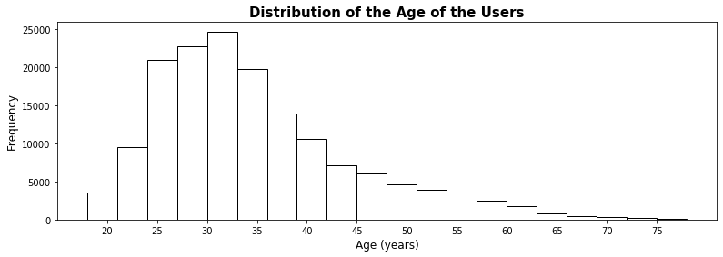

```python
bins=np.arange(18,81,3)
plt.figure(figsize=[13,4])
ax=plt.hist(data=bike_df_clean,x='age',bins=bins, fill=False)
plt.xticks(np.arange(20,80,5))
plt.xlabel('Age (years)',size=12)
plt.ylabel('Frequency', size=12)
plt.title('Distribution of the Age of the Users',size=15, fontweight='bold');
```

### Relationship Between Gender and Bike Sharing

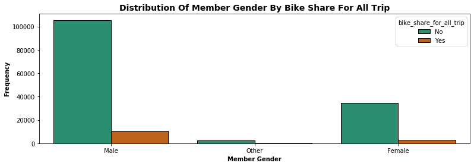

```python
myCountPlot(bike_df_clean,'member_gender',hueVar='bike_share_for_all_trip', palette='Dark2')
```

### Relationship Between Gender and User Type

> All genders are more of a subscriber than a customer

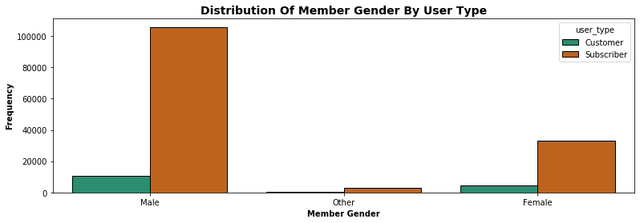

```python
myCountPlot(bike_df_clean,'member_gender',hueVar='user_type', palette='Dark2')
```

### Relationship between User Type and Bike Share

From the plot below,

> Most subscribers didn't share their bikes during their trips, and customers didnt share their bikes at all

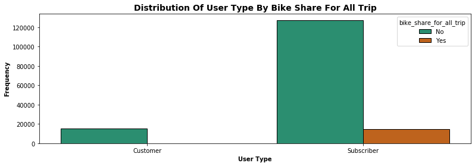

```python
myCountPlot(bike_df_clean,'user_type',hueVar='bike_share_for_all_trip', palette='Dark2')
```

### Relationship Between Member Gender and Day of the Week

> From the plot below, it shows that most of the riders are either male or female and ride mostly during weekdays

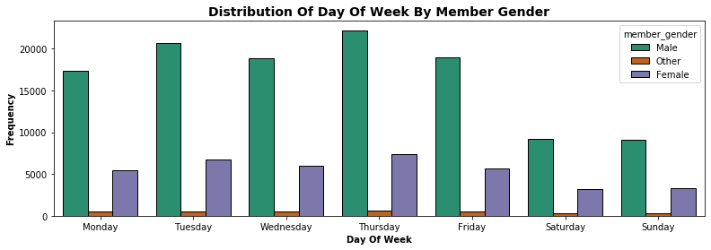

```python
myCountPlot(bike_df_clean,'day_of_week',hueVar='member_gender', palette='Dark2', order=day_order)
```

### Relationship Between Member Gender and Day Time

From the figure below:

> For male riders, it shows that they ride more in the morning, followed by evening and then least in the afternoon

> For female and the other gender, it shows that they ride more in the morning, followed by afternoon and then least in the evening

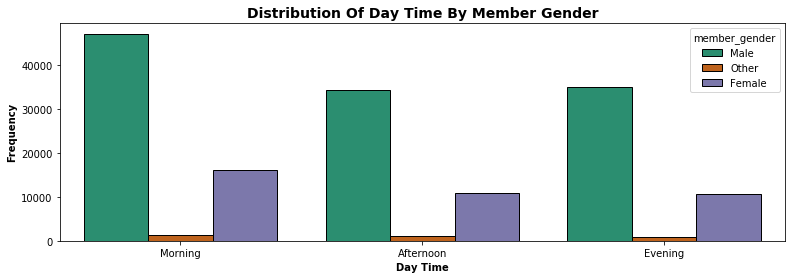

```python
myCountPlot(bike_df_clean,'day_time',hueVar='member_gender', palette='Dark2', order=time_order)
```

### Relationship Between User Type and Day of the Week

> The figure below shows that there were more subscriber bikers riding during the weekdays than weekends

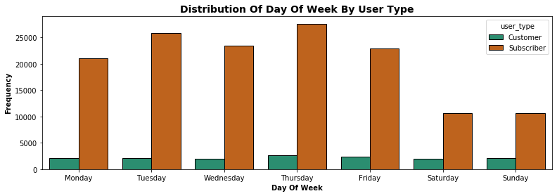

```python
myCountPlot(bike_df_clean,'day_of_week',hueVar='user_type', palette='Dark2', order=day_order)
```

### Relationship Between Day Time and User Type

> For subscribers, they tend to ride more in the morning than in the evening than in the afternoon For customers, they tend to ride more in the Afternoon than in the morning than in the evening

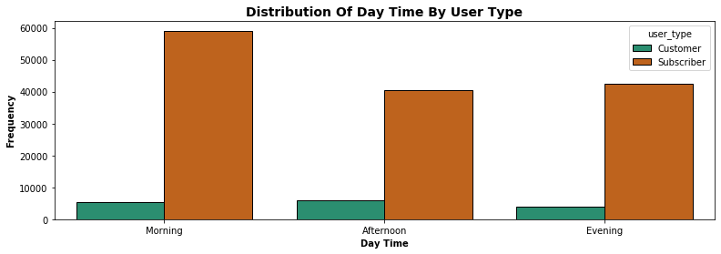

```python
myCountPlot(bike_df_clean,'day_time',hueVar='user_type', palette='Dark2', order=time_order)
```

##### Relationship Between Day Time and Day of the Week

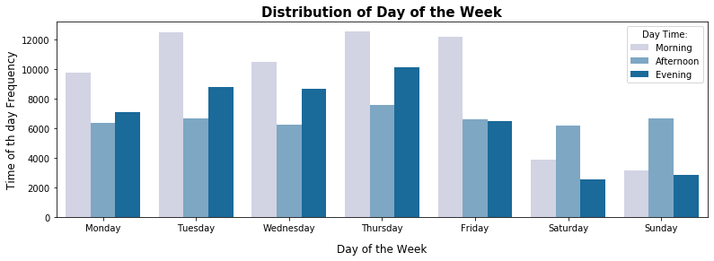

```python
plt.figure(figsize=[13,4])
sb.countplot(data=bike_df_clean,x='day_of_week',hue='day_time', order=day_order, hue_order=time_order, palette='PuBu')
plt.xlabel('Day of the Week', size=12, labelpad=12)
plt.ylabel('Time of th day Frequency', size=12)
plt.legend(title='Day Time:')
plt.title('Distribution of Day of the Week', fontweight='bold',fontsize=15);
```